# Lab 6: Summarizing data within groups using `group_by()` and `mutate()`

### Learning Objectives

- calculating within groups statistics using `group_by()` and `mutate()`
- learning when to apply `mutate()` and when to apply `summarize()`

### 0. Introduction

Let’s load in our `prodsales` data from Lab 5.

```r
library(tidyverse)
prodsales <- read_csv("prodsales.csv")
```

### 1. Calculating within groups statistics using `group_by()` and `mutate()`

Our `prodsales` data has the average price for each product. Since some product categories, such as pasta sauce, tend to be more expensive than others, such as pasta, let’s calculate how prices of individual products differ from the average prices their product category. This means that we need to calculate average price within a category, but we don’t want the data to collapse. We want a new variable in `prodsales` that has the average price in each category. We can accomplish this using functions `group_by()` and `mutate()`. This is because `mutate()` calculates summary statistics within groups defined by `group_by()`.

```r
prodsales <- prodsales %>% group_by(commodity) %>% mutate(av_cat_price=mean(av_price))
head(select(prodsales, product_description, commodity, av_price, av_cat_price), n=5)
```

[output not shown]

Notice that we grouped data by product category (variable `commodity`). The number of observations is still 926. We also see that `av_cat_price` is the same in rows that have the same category. Let’s calculate how each product’s price deviates from the average price in its category. Then, let’s plot this deviation against number of transactions. We may want to use log scale for the number of transactions. Also, to make the graph more informative let’s vary the color by product category.

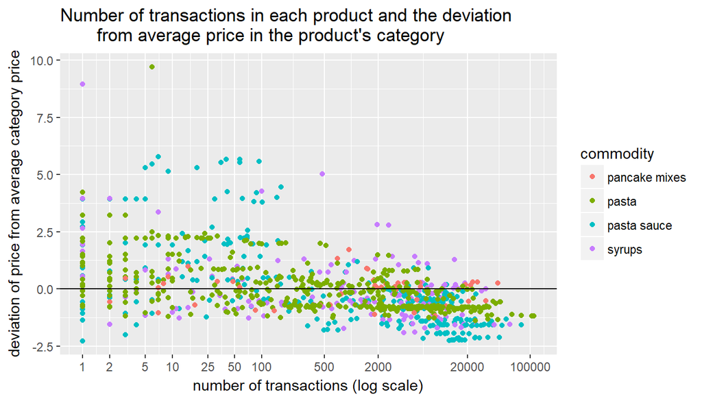

```r
prodsales$price_dev <- prodsales$av_price - prodsales$av_cat_price
ggplot(prodsales, aes(y=price_dev,x=no_trans,color=commodity)) + geom_point() +
  scale_x_continuous(trans="log", breaks=c(1, 2, 5, 10, 25, 50, 100,500,2000, 20000,100000)) +
  labs(title="Number of transactions in each product and the deviation
       from average price in the product's category") +
  ylab("deviation of price from average category price") +
  xlab("number of transactions (log scale)") +
  geom_hline(aes(yintercept=0))
```

### IN-CLASS EXERCISE:

1. Calculate the market share of each brand in its product category. Create a data frame with top three brands in each category.
2. Suppose we wanted to predict the outcome of game in our NHL data set. What variables would you want to use?
3. (`cumsum()` function) Suppose you wanted to create a measure of the opposing teams success so far in the season. Suppose further that you wanted to measure that success by counting the number of games won so far in the season. Create a variable that calculates that number for each team (home and visiting) for each game. The code below is to get you started. Can you tell what it does?

```r
nhl <- read_csv("NHLseason2016.csv")
home_games <- nhl %>%
              rename(team=Home, goals_for=goals_home, goals_against=goals_visit) %>%
              select(Date, team, goals_for, goals_against)
away_games <- nhl %>%
              rename(team=Visitor, goals_for=goals_visit, goals_against=goals_home) %>%
              select(Date, team, goals_for, goals_against)
games <- bind_rows(home_games, away_games)
games$win <- ifelse(games$goals_for-games$goals_against>0,1,0)
games <- arrange(games, team, Date)
```

### Exercises:

In solving the type of problems below you normally need to make three decision: First, decide whether you need to *collapse* the data or just *calculate a new column* based on some groups (i.e. `summarize` vs. `mutate`). Second, decide *by which group* or groups you want to collapse or make a calculations (i.e. which variable(s) go into `group_by()`). Finally, decide *what calculation(s)* need to happen when you collapse or mutate (i.e. which functions, `=sum(), =mean(), =n() etc.` go inside `summarize` or `mutate`).

1. Load in dunnhumby’s `trans` data and filter out negative sales. Load in the `prods` data as well. Fix the `upc` code in `prods` so that it is a 10-digit character with leading zeros where needed. We did this in lab 5.
2. How many different brands exist in each product category? (Hint 1: You will need to collapse data twice. Hint 2: It is possible to collapse data without making any calculations. For example, `df2 <- df %>% group_by(a,b) %>% summarize()` will return columns `a` and `b` and one row for each combination of values in `a` and `b` that exists in `df`.)
3. Let’s examine brand loyalty. As a first step, let’s focus on transactions from frequent buyers in each category. Create data that has only transactions from households and product categories in which the household made at least 10 transactions in that product category. How many transactions did we lose by eliminating infrequent buyers? (Hint: Since transaction data only has upc but not product category, you will need to merge-in product category into the transaction data.)
4. Among households who bought at least 10 items in a product category (i.e. the data you created in the previous question), what is the median number of brands in each product category that households buy? (Hint 1: You will need to “collapse” your data three times. Hint 2: The medium number of brands of pasta that households buy is 4.)
5. Would you say that brand loyalty varies by product category?